# Designing a package

11/29/2019

## Using code from other packages

In your code `/R`, you have these options:

1. Prefix with the package name `package::object`
2. Import the entire package `@import package`
3. Import specific functions `@importFrom package object`

You absolutely cannot use `library(package)` or `require(package)` anywhere in `/R`.

It is OK to use `library(package)` in vignettes and tests

## Imports and Depends in DESCRIPTION

These fields determine what happens at installation and `library` ing your package.

- If a package appears in `Imports:` it will be installed along with your package (if needed).
- If a package appears in `Depends:` it will be installed, *and* loaded into the namespace with `library` when *your* package is loaded.

Thus,

- If you are using external functions in your code, but users will not need to call them directly, use `Imports`
- If users will likely be calling functions from another package while using yours, use `Depends`

## Outline

1. General principles
2. Naming things is hard
3. Designing user interfaces
4. Appealing to users

## General Prinicples

- Consider your audience
  - Yourself
  - Colleagues
  - Experienced statisticians
  - “General public”
- Reduce cognitive burden (users and developers)
- Be internally consistent
- Get input early and often

## About cognitive burden

It is difficult to keep a large number of objects in working memory

- Large number of arguments
- Different naming conventions
- Varying code patterns/data structures
- Distinct mental models

All contribute to the cognitive load

## Consistency

## Examples

```r
stats::t.test(mpg ~ vs, data = mtcars)
stats::cor(mpg, hp, data = mtcars)
```

```r
names; colnames
row.names; rownames
rowSums; rowsum
```

## Examples

[charlatan](https://docs.ropensci.org/charlatan/reference/index.html)

## Naming things is hard

```r
camelCase
snake_case
dot.case
lowercase
```

[Tidyverse style guide](https://style.tidyverse.org/)

## Function and object names

- Functions are generally verbs or adverbs
- Tidyverse follow the `object_verb` convention for functions
- If appropriate, functions and arguments should match standard mathematical notation
- Avoid using dots in object names (do as I say not as R does)

## File names

- Organize objects into different files
- Filenames should be descriptive, and machine readable
- Reduce your own cognitive burden

[Example](https://github.com/aronlindberg/generic_oss_functions/tree/master/R)

[Example 2](https://github.com/yihui/knitr/tree/master/R)

## What to call your package

> The mandatory ‘Package’ field gives the name of the package. This should contain only (ASCII) letters, numbers and dot, have at least two characters and start with a letter and not end in a dot.

Recommendation:

- One word, all lower case
- Clever or memorable
- Clear connection to the usage of the package
- Use abbreviations
- Use an R pun

```r
ggplot2, foreign, Rcpp, plyr, knitr, tourr, tinytex
```

## Semantic versioning

What to number your package? Package numbers conveys information about differences between versions. There are different systems, your should use one:

1. `major.minor.patch`
2. `api-change.feature-addition.bugfixes`
- Only release `major.minor` versions to CRAN, and keep patches tracked on github.
- Two digits are fine, e.g., `1.11`.
- `1.0.0` to me signifies maturity, I would not rely on a package until it reaches `1.0`

## User interfaces

- Design for the end-to-end user workflow
- Vignette-driven development
- The workflow should match the domain-specific application you aim to solve

## Examples

[Clinicaltrials.gov](https://clinicaltrials.gov/)

```r
library(rclinicaltrials)

z <- clinicaltrials_search(query = 'lime+disease')
clinicaltrials_count(query = "myeloma")
y <- clinicaltrials_download(z, count = 10,
                             include_results = TRUE)
```

## Examples

Principal surrogate evaluation with `pseval`

```r
surv.fit <- psdesign(fakedata, Z = Z, Y = Surv(time.obs, event.obs),
                     S = S.obs, BIP = BIP, CPV = CPV) +
  integrate_semiparametric(formula.location = S.1 ~ BIP,
                           formula.scale = S.1 ~ 1) +
  risk_exponential(D = 10) + ps_estimate(method = "BFGS") +
    ps_bootstrap(n.boots = 20)
surv.fit
plot(surv.fit)
calc_risk(surv.fit, contrast = "TE")
```

## Examples

[Surrogate](https://cran.r-project.org/web/packages/Surrogate/Surrogate.pdf)

## Communicating with the user

Be consistent across multiple entry points

- CRAN homepage (Description)
- Vignettes
- Github homepage (Readme)
- Package documentation

## Communicating in functions

- Catch errors early
- Write helpful error messages
- Address common errors via messages/documentation
- Design out common errors if possible

## Message

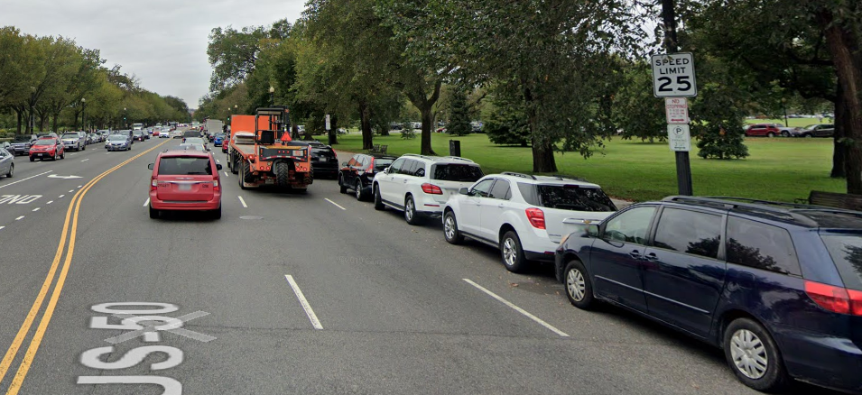

dc

## Design away

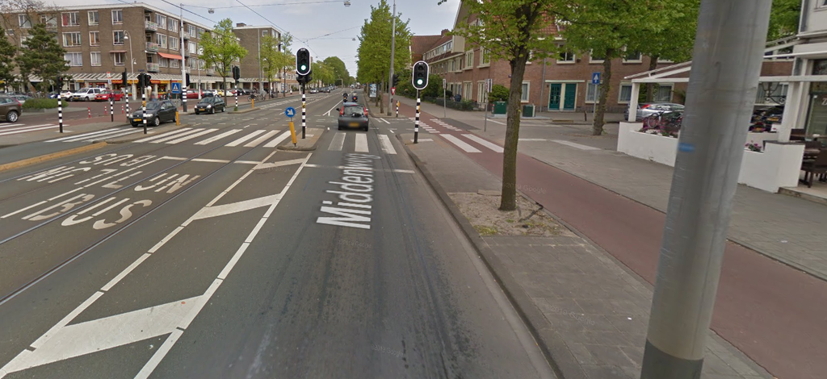

ams

## Don’t get too ambitious

- Make your package compatible with the workflow
  - If survival related, use `Surv`
  - If graph related, use `igraph`
  - …
- Focus on creating sensible/tidy data output
  - Allows you to farm out plotting, e.g.

## The `/inst` subdirectory

Anything in the `/inst` directory of your package will be copied as-is to the top level directory when the package is installed. It is useful for including things like

- Shiny apps
- Rmarkdown templates or other templates
- External code

Within R you refer to such files with

`system.file("path-to-file", package = "packagename")`

## Appealing to users

## Criteria

Should the package exist?

1. Does it solve a problem that other people have?
2. Is it unique?
3. Is it more useful/usable than alternatives?

## Do you appear trustworthy?

1. Have a big peer network
2. Forced competence
3. Peer review if possible
4. Demonstrate competence through vignettes, tests, documentation, etc.

## Summary

1. Think about your target audience
2. Manage their/your cognitive burden through better code design
3. Remember there are multiple points of entry/exposure for your package, ensure that they all lead to success.